# Homework 01

## Question 1 (Least squares and matrix calculations)

Set the random seed to 43201. Generate $n=100$ observations with $p=5$ predictors according to

$$x_{ij}\overset{\mathrm{iid}}{\sim}N(0,1),
\qquad
\varepsilon_i\overset{\mathrm{iid}}{\sim}N(0,0.7^2),$$

with all predictors and errors generated independently. Let

$$\mathbf X
=
\begin{bmatrix}
\mathbf 1 & \mathbf x_1 & \cdots & \mathbf x_5
\end{bmatrix},
\qquad
\boldsymbol\beta
=
(3,1.4,-0.9,0.7,0,1.1)^{\mathsf T},$$

and generate

$$\mathbf y=\mathbf X\boldsymbol\beta+\boldsymbol\varepsilon.$$

1. Generate the data and report the dimensions and rank of $\mathbf X$. Calculate the least-squares estimate $\widehat{\boldsymbol\beta}$ using a numerically stable least-squares routine, without explicitly calculating $(\mathbf X^{\mathsf T}\mathbf X)^{-1}$. Compare the estimates with the coefficients used to generate the data.
2. Calculate the fitted values, the residual vector $\mathbf r=\mathbf y-\mathbf X\widehat{\boldsymbol\beta}$, and the training root mean squared error

$$\operatorname{RMSE}
=
\left(
\frac{1}{n}\sum_{i=1}^{n}r_i^2
\right)^{1/2}.$$

3. Report $\lVert\mathbf X^{\mathsf T}\mathbf r\rVert_\infty$. Explain why this value should be close to zero and what it tells us about the residual vector.

## Solution to Question 1

### (a)

Generate the design matrix and response using the fixed seed:

```r
set.seed(43201)

n <- 100
p <- 5
X <- cbind(1, matrix(rnorm(n * p), nrow = n, ncol = p))
beta <- c(3, 1.4, -0.9, 0.7, 0, 1.1)
eps <- rnorm(n, mean = 0, sd = 0.7)
y <- X %*% beta + eps

dim(X)
```

```
[1] 100   6
```

```r
qr(X)$rank
```

```
[1] 6
```

The matrix `X` has dimensions $100 \times 6$ because there is an intercept plus 5 predictors. Since the predictors are generated independently from a continuous distribution, the columns are linearly independent with probability 1, so the rank should be 6.

To estimate the coefficients without explicitly forming $(X^T X)^{-1}$, use a numerically stable least-squares routine:

```r
fit <- lm.fit(x = X, y = y)
beta_hat <- fit$coefficients
beta_hat
```

```
        x1         x2         x3         x4         x5         x6
 3.0063210  1.4171604 -0.8883453  0.7952834  0.0484378  1.1319341
```

This produces the least-squares estimate $\widehat{\beta}$. It should be close to the true coefficients used to generate the data, though not exactly equal because of random noise. In particular, the estimates should be near $(3, 1.4, -0.9, 0.7, 0, 1.1)^T$ up to sampling error.

### (b)

Compute fitted values, residuals, and RMSE:

```r
y_hat <- X %*% beta_hat
r <- y - y_hat
rmse <- sqrt(mean(r^2))

rmse
```

```
[1] 0.6763696
```

The residual vector is

$$\mathbf r = \mathbf y - \mathbf X\widehat{\boldsymbol\beta},$$

and the training RMSE is

$$\mathrm{RMSE} = \left(\frac{1}{n}\sum_{i=1}^{n} r_i^2\right)^{1/2}.$$

This measures the typical size of the prediction error on the training data. A smaller RMSE means the fitted model explains the observed outcomes better.

### (c)

Now compute $\|X^T r\|_\infty$:

```r
Xtr <- crossprod(X, r)
max_abs <- max(abs(Xtr))
max_abs
```

```
[1] 1.287859e-14
```

This quantity should be extremely close to zero because the least-squares estimator satisfies the normal equations:

$$\mathbf X^T(\mathbf y - \mathbf X\widehat{\boldsymbol\beta}) = \mathbf X^T\mathbf r = \mathbf 0.$$

In words, the residual vector is orthogonal to every column of the design matrix. That means the residuals contain no remaining linear information that the predictors can explain. The infinity norm measures the largest absolute component of $X^T r$, so being close to zero indicates the fitted model has removed the linear structure explainable by the predictors.

This is a key property of least squares: the residuals are not random noise with respect to the fitted design matrix; they are the part of $y$ left after projecting onto the column space of $X$.

## Question 2 (Gaussian likelihood for linear regression)

Continue with the data from Question 1. Suppose

$$\mathbf Y\mid\mathbf X
\sim
N_n\left(\mathbf X\boldsymbol\beta,\sigma^2\mathbf I_n\right).$$

The log-likelihood, including the constant term, is

$$\ell(\boldsymbol\beta,\sigma^2)
=
-\frac{n}{2}\log(2\pi\sigma^2)
-\frac{1}{2\sigma^2}
(\mathbf y-\mathbf X\boldsymbol\beta)^{\mathsf T}
(\mathbf y-\mathbf X\boldsymbol\beta).$$

1. For fixed $\sigma^2$, explain why maximizing $\ell(\boldsymbol\beta,\sigma^2)$ over $\boldsymbol\beta$ is equivalent to minimizing the residual sum of squares. What does this imply about the maximum-likelihood estimate of $\boldsymbol\beta$?
2. For fixed $\boldsymbol\beta$, differentiate the log-likelihood with respect to $\sigma^2$ and derive its maximum-likelihood estimate. Calculate this estimate at $\widehat{\boldsymbol\beta}$ and compare it with the unbiased estimate of $\sigma^2$. Explain why the two denominators differ.
3. Let

$$\mathbf e_{x_2}=(0,0,1,0,0,0)^{\mathsf T}.$$

Using the variance estimate from part b, plot

$$\ell\left(
\widehat{\boldsymbol\beta}+t\mathbf e_{x_2},
\widehat{\sigma}_{\mathrm{MLE}}^2
\right)$$

over a grid of $t$ values from $-1.25$ to $1.25$. State where the maximum occurs and explain why this agrees with the least-squares result.

## Solution to Question 2

### (a)

For fixed $\sigma^2$, the only part of the log-likelihood that depends on $\boldsymbol\beta$ is

$$-\frac{1}{2\sigma^2}
(\mathbf y-\mathbf X\boldsymbol\beta)^T
(\mathbf y-\mathbf X\boldsymbol\beta).$$

Therefore, maximizing the log-likelihood is equivalent to minimizing the residual sum of squares. Thus,

$$\widehat{\boldsymbol\beta}_{\mathrm{MLE}}
=
\widehat{\boldsymbol\beta}_{\mathrm{LS}}.$$

So the maximum-likelihood estimate of $\boldsymbol\beta$ is the same least-squares estimate calculated in Question 1.

### (b)

For fixed $\boldsymbol\beta$, differentiate the log-likelihood with respect to $\sigma^2$:

$$\frac{\partial \ell}{\partial \sigma^2}
=
-\frac{n}{2\sigma^2}
+
\frac{\mathrm{RSS}}{2(\sigma^2)^2}.$$

Setting this equal to zero gives

$$\widehat{\sigma}^2_{\mathrm{MLE}}
=
\frac{\mathrm{RSS}}{n}.$$

Calculate the MLE and the unbiased estimate:

```r
RSS <- sum(r^2)

sigma2_mle <- RSS / n
sigma2_unbiased <- RSS / (n - qr(X)$rank)

sigma2_mle
```

```
[1] 0.4574759
```

```r
sigma2_unbiased
```

```
[1] 0.4866765
```

The MLE is approximately $0.4575$, while the unbiased estimate is approximately $0.4867$. The MLE divides by $n=100$, while the unbiased estimate divides by $n-6=94$ because six regression coefficients were estimated from the data. The smaller denominator corrects for the degrees of freedom used to estimate these coefficients.

### (c)

Vary only the coefficient of $x_2$ around its least-squares estimate:

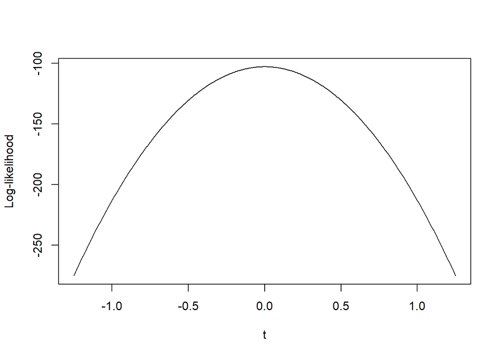

```r
e_x2 <- c(0, 0, 1, 0, 0, 0)

t_grid <- seq(-1.25, 1.25, length.out = 501)

loglik <- function(t) {
  beta_t <- beta_hat + t * e_x2
  residual_t <- y - X %*% beta_t

  -n / 2 * log(2 * pi * sigma2_mle) -
    sum(residual_t^2) / (2 * sigma2_mle)
}

loglik_values <- sapply(t_grid, loglik)

plot(
  t_grid, loglik_values,
  type = "l",
  xlab = "t",
  ylab = "Log-likelihood"
)
```

```r
t_grid[which.max(loglik_values)]
```

```
[1] 0
```

The maximum occurs at $t=0$. This means that moving the $x_2$ coefficient away from its least-squares estimate decreases the log-likelihood. This agrees with part (a), since the least-squares estimate is also the maximum-likelihood estimate of $\boldsymbol\beta$.

## Question 3 (Starting values in nonconvex optimization)

Consider the function

$$f(x)=\exp(1.5x)-3(x+6)^2-0.05x^3,$$

with derivative

$$f'(x)=1.5\exp(1.5x)-6(x+6)-0.15x^2.$$

1. Plot $f(x)$ over the interval $[-40,7]$. Based on the plot, describe the important features of the objective function that may affect numerical optimization.
2. Use BFGS to minimize $f(x)$ twice, starting at $x^{(0)}=-15$ and $x^{(0)}=0$. Supply $f'(x)$ to the optimizer. For each run, report the final value of $x$, the final objective value, $|f'(x)|$, and whether the optimizer reported convergence.
3. Explain why the two runs can converge to different answers. Which run gives the lower objective value? What additional evidence would be needed before claiming that this point is the global minimum?

## Solution to Question 3

### (a)

Define the objective function and its derivative, and plot the objective over the requested interval:

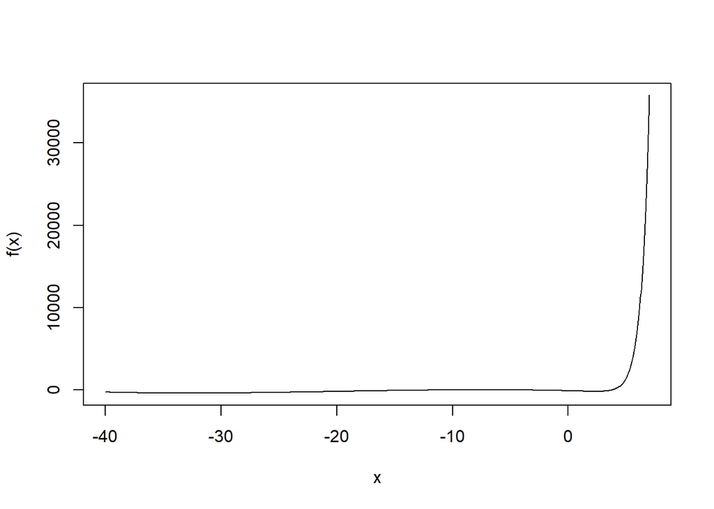

```r
f <- function(x) {
  exp(1.5 * x) - 3 * (x + 6)^2 - 0.05 * x^3
}

f_prime <- function(x) {
  1.5 * exp(1.5 * x) - 6 * (x + 6) - 0.15 * x^2
}

x_grid <- seq(-40, 7, length.out = 1000)

plot(
  x_grid, f(x_grid),
  type = "l",
  xlab = "x",
  ylab = "f(x)"
)
```

The plot shows that the objective is nonconvex, with multiple local extrema. In particular, there are two local minima separated by a local maximum. Therefore, the result of numerical optimization may depend on the starting value.

### (b)

Run BFGS from the two requested starting values:

```r
run_bfgs <- function(start) {
  fit <- optim(
    par = start,
    fn = f,
    gr = f_prime,
    method = "BFGS"
  )

  data.frame(
    start = start,
    x_final = fit$par,
    objective = fit$value,
    abs_gradient = abs(f_prime(fit$par)),
    convergence = fit$convergence
  )
}

results <- rbind(
  run_bfgs(-15),
  run_bfgs(0)
)

results
```

```
  start    x_final objective abs_gradient convergence
1   -15 -32.649111 -390.3858 8.725087e-08           0
2     0   2.349967 -175.8626 6.556057e-07           0
```

Starting at $x=-15$ leads to approximately $x=-32.65$, with an objective value near $-390.39$. Starting at $x=0$ leads to approximately $x=2.35$, with an objective value near $-175.86$. In both cases, the gradient is close to zero and a convergence code of 0 indicates successful convergence.

### (c)

The two runs converge to different answers because the objective function is nonconvex and contains more than one local minimum. BFGS is a local optimization method, so its result can depend on the starting value.

The run starting at $x=-15$ gives the lower objective value. However, finding a lower local minimum does not by itself prove that it is the global minimum. Additional evidence, such as examining the objective over a wider range or identifying all stationary points and the behavior of the function in the tails, would be needed.

## Question 4 (Nearly collinear predictors)

Continue with $\mathbf X$ and $\mathbf y$ from Question 1. Set the random seed to 43202 and generate

$$u_i\overset{\mathrm{iid}}{\sim}N(0,1),
\qquad i=1,\ldots,n.$$

Define

$$\mathbf x_6=\mathbf x_1+10^{-4}\mathbf u,
\qquad
\mathbf X_+
=
\begin{bmatrix}
\mathbf X & \mathbf x_6
\end{bmatrix},$$

and let

$$\mathbf y^\star=\mathbf y+10^{-3}\mathbf u.$$

Use a numerically stable least-squares routine throughout.

1. Fit $\mathbf y$ using $\mathbf X$ and $\mathbf X_+$. For each design matrix, report the condition number and training RMSE. For the augmented fit, also report the coefficients of $\mathbf x_1$ and $\mathbf x_6$.
2. Fit $\mathbf y^\star$ using $\mathbf X_+$. Report the changes in the coefficients of $\mathbf x_1$ and $\mathbf x_6$. Compare the two fitted-value vectors using their root mean squared difference and maximum absolute difference.
3. Use the identity

$$\mathbf y^\star-\mathbf y
=
10(\mathbf x_6-\mathbf x_1)$$

to explain why the fitted values change very little while the two coefficients change substantially. What does this example suggest about interpreting separate effects for nearly collinear predictors?

## Solution to Question 4

### (a)

```r
set.seed(43202)

u <- rnorm(n)

x6 <- X[, 2] + 1e-4 * u
X_plus <- cbind(X, x6)

fit_X <- lm.fit(x = X, y = y)
fit_plus <- lm.fit(x = X_plus, y = y)

# Condition numbers and RMSE
data.frame(
  design = c("X", "X_plus"),
  condition_number = c(kappa(X, exact = TRUE), kappa(X_plus, exact = TRUE)),
  RMSE = c(sqrt(mean(fit_X$residuals^2)), sqrt(mean(fit_plus$residuals^2)))
)
```

```
  design condition_number      RMSE
1      X         1.524914 0.6763696
2 X_plus     20209.203501 0.6754668
```

```r
# Coefficients of x1 and x6 from X_plus fit
data.frame(
  coefficient = c("x1", "x6"),
  estimate = unname(fit_plus$coefficients[c(2, 7)])
)
```

```
  coefficient  estimate
1          x1  351.6766
2          x6 -350.2588
```

### (b)

```r
y_star <- y + 1e-3 * u

fit_star <- lm.fit(x = X_plus, y = y_star)

coef_star <- fit_star$coefficients
coef_change <- coef_star - fit_plus$coefficients

# Coefficient changes for x1 and x6
data.frame(
  coefficient = c("x1", "x6"),
  original = fit_plus$coefficients[c(2, 7)],
  new = coef_star[c(2, 7)],
  change = coef_change[c(2, 7)]
)
```

```
   coefficient  original       new change
            x1  351.6766  341.6766    -10
x6          x6 -350.2588 -340.2588     10
```

```r
# Compare fitted values
fitted_plus <- X_plus %*% fit_plus$coefficients
fitted_star <- X_plus %*% coef_star

fitted_difference <- fitted_star - fitted_plus

data.frame(
  RMSE_difference = sqrt(mean(fitted_difference^2)),
  max_absolute_difference = max(abs(fitted_difference))
)
```

```
  RMSE_difference max_absolute_difference
1     0.001015879             0.002572675
```

### (c)

The small change from $\mathbf y$ to $\mathbf y^\star = \mathbf y + 10^{-3}\mathbf u$ can be explained by the relationship:

$$\mathbf y^\star - \mathbf y = 10^{-3}\mathbf u = 10(\mathbf x_6 - \mathbf x_1).$$

This means the response changed by exactly 10 times the difference between the two nearly collinear predictors. Since $\mathbf x_6$ and $\mathbf x_1$ are nearly identical, the model can represent this small change by decreasing the coefficient of $\mathbf x_1$ by approximately 10 and increasing the coefficient of $\mathbf x_6$ by approximately 10. These large but opposite coefficient changes mostly cancel when computing fitted values $\mathbf X_+\widehat{\boldsymbol\beta}$, so predictions remain stable.

This demonstrates a fundamental problem with nearly collinear predictors: individual coefficient estimates can be highly unstable and subject to large swings from small data perturbations, even when the fitted values remain stable. Therefore, when predictors are nearly collinear, interpretation of separate effects for each predictor should be done with considerable caution. The individual coefficients may not be reliable, but linear combinations of coefficients (like fitted values) can still be well-estimated.

## Question 5 (Data preparation and summary statistics)

The file `data/data-manipulation.csv` is a small constructed data table containing an observation identifier, a group label, two numeric predictors, and a response. Some response values are missing. For analyses involving the response, use only observations with a recorded response. Do not replace a missing response with zero or a group mean.

1. Read the data and report its dimensions, column types, number of duplicated identifiers, and number of missing values in each column. Create an analysis table containing only observations with a recorded response, and define

$$\texttt{feature\_sum}=\texttt{x1}+\texttt{x2}.$$

2. For each group, report the number of observations, the mean response, and the mean of `feature_sum`. State clearly which observations these summaries describe.
3. Sort the analysis table by response from largest to smallest and report the first three rows, including `observation_id`, `group`, `response`, and `feature_sum`. Add code checks verifying that the number of retained rows equals the number of nonmissing responses in the original data, that the analysis table has no missing response values, and that its identifiers are unique.

## Solution to Question 5

### (a)

Read the data and inspect its dimensions, column types, duplicated identifiers, and missing values:

```r
dat <- read.csv("data/data-manipulation.csv")

dim(dat)
```

```
[1] 24  5
```

```r
sapply(dat, class)
```

```
observation_id          group             x1             x2       response
   "character"    "character"      "numeric"      "numeric"      "numeric"
```

```r
sum(duplicated(dat$observation_id))
```

```
[1] 0
```

```r
colSums(is.na(dat))
```

```
observation_id          group             x1             x2       response
             0              0              0              0              3
```

The original data have 24 observations and 5 variables. `observation_id` and `group` are character variables, while `x1`, `x2`, and `response` are numeric. There are no duplicated identifiers, and only `response` has missing values, with 3 missing observations.

For analyses involving the response, retain only observations with a recorded response and create `feature_sum`:

```r
analysis <- dat[!is.na(dat$response), ]

analysis$feature_sum <- analysis$x1 + analysis$x2

dim(analysis)
```

```
[1] 21  6
```

Thus, `analysis` contains only observations for which the response is observed. Missing response values are excluded rather than replaced.

### (b)

Calculate the requested summary statistics separately for each group:

```r
group_summary <- do.call(
  rbind,
  lapply(split(analysis, analysis$group), function(d) {
    data.frame(
      n = nrow(d),
      mean_response = mean(d$response),
      mean_feature_sum = mean(d$feature_sum)
    )
  })
)

group_summary
```

```
  n mean_response mean_feature_sum
A 7      5.600000         3.600000
B 7      7.602857         4.928571
C 7      7.997143         6.585714
```

These summaries describe only the observations retained in the analysis table, meaning observations with nonmissing response values. The number of observations, mean response, and mean `feature_sum` are calculated separately within each group.

### (c)

Sort the analysis table from the largest response to the smallest and report the first three observations:

```r
sorted_analysis <- analysis[order(analysis$response, decreasing = TRUE), ]

top_three <- sorted_analysis[
  1:3,
  c("observation_id", "group", "response", "feature_sum")
]

top_three
```

```
   observation_id group response feature_sum
22         obs-22     C     9.24         6.6
16         obs-16     B     9.00         5.2
14         obs-14     B     8.66         5.0
```

Finally, verify that the analysis table was constructed correctly:

```r
nrow(analysis) == sum(!is.na(dat$response))
```

```
[1] TRUE
```

```r
!any(is.na(analysis$response))
```

```
[1] TRUE
```

```r
anyDuplicated(analysis$observation_id) == 0
```

```
[1] TRUE
```

The first confirms that every observation with a recorded response was retained, the second confirms that no missing responses remain in the analysis table, and the third confirms that the retained observation identifiers are unique.

## Question 6 (Can 39 million Fitbit records represent US adults?)

[Patten et al. (2026)](https://doi.org/10.1038/s41591-026-04352-3) describe Fitbit data from 59,018 participants in the All of Us Research Program. The dataset spans 14 years and contains more than 39 million daily step records. Participants contributed data through one of two routes:

- Bring Your Own Device (BYOD): participants shared data from a Fitbit they already owned.
- Wearables Enhancing All of Us Research (WEAR): invited participants received a Fitbit at no cost.

In the general activity cohort, the BYOD and WEAR groups contained 32,035 and 22,474 participants, respectively. The BYOD value is listed first in each comparison below:

- 77.3% versus 55.1% reported being White;
- 6.1% versus 15.2% reported annual household income between $\$10{,}000$ and $\$25{,}000$; and
- median daily steps were 6,867 versus 5,797.

Suppose the target is the mean of the participant-specific average daily step counts among US adults during the study period, with each adult given equal weight. A researcher writes:

> “This dataset contains more than 39 million daily Fitbit records. Therefore, the average of all recorded step counts should provide an accurate estimate of mean daily activity among US adults.”
1. Are the 39 million daily records independent observations? What characteristics or behaviors could cause some participants to contribute more recorded days than others? Explain how averaging all recorded days would then weight participants unequally.
2. BYOD participants reported a median of 6,867 daily steps, compared with 5,797 among WEAR participants. Does this comparison show that already owning a Fitbit causes people to walk more? Explain your answer and give at least one plausible alternative explanation based on how participants entered the two groups.
3. A very large dataset can still produce a biased estimate of a population quantity when the people and observations entering the dataset are selected. Using this study, explain how selection of both participants and recorded days could make the observed data differ from the US adult population. Why might the naive average of all recorded daily step counts fail to estimate the stated target? You do not need to determine the direction of the bias.

### Source

Patten, T., Preble, E. A., Master, H., et al. (2026). [The All of Us Research Program’s wearables dataset](https://doi.org/10.1038/s41591-026-04352-3). *Nature Medicine*, 32, 2302-2310.

## Solution to Question 6

### (a)

The 39 million daily records are not independent because many records come from the same participants. Some people may wear their Fitbit regularly, while others may forget to wear it or use it only occasionally. Therefore, participants who contribute more recorded days receive more weight when all daily records are averaged together.

### (b)

No. The higher median step count among BYOD participants does not show that owning a Fitbit caused them to walk more. People who already owned a Fitbit may have bought it because they were already more interested in exercise or tracking their activity. In contrast, WEAR participants received a Fitbit through the study and may not have had the same motivation or habits before joining.

### (c)

The dataset can still be biased even though it is very large. The participants may not represent all US adults because people who choose to participate and share wearable data may be more interested in health or exercise than the general population. In addition, the recorded days may also be selective because participants may wear the Fitbit more consistently on some days than others. Therefore, averaging all recorded daily step counts can give more weight to certain participants and certain types of days, so it may not estimate the mean activity of US adults accurately.